# Basic of the R lenguage

### Data Frames

A data frame is a very important data type in R. It’ the structure for most data we use for statistics and the default object in software such as `Stata`, `SAS`, `SPSS`, etc. Unlike vectors and matrices, the content of a data frame is not restricted to a single type and can encompass any mixture of data types. As in matrices, however, in a data frame every element (or “variable) has to have same length (i.e. same number of”observations“).

```r
# create a data frame
mydata <- data.frame(id = letters[1:10], x = 1:10, y = 11:20); mydata
```

| id | x | y |
| --- | --- | --- |
| a | 1 | 11 |
| b | 2 | 12 |
| c | 3 | 13 |
| d | 4 | 14 |
| e | 5 | 15 |
| f | 6 | 16 |
| g | 7 | 17 |
| h | 8 | 18 |
| i | 9 | 19 |
| j | 10 | 20 |

```r
# access variables in a data frame
mydata$x
```

```
##  [1]  1  2  3  4  5  6  7  8  9 10
```

```r
# assign a new element to a data frame

mydata$z <- mydata$x + mydata$y; mydata
```

| id | x | y | z |
| --- | --- | --- | --- |
| a | 1 | 11 | 12 |
| b | 2 | 12 | 14 |
| c | 3 | 13 | 16 |
| d | 4 | 14 | 18 |
| e | 5 | 15 | 20 |
| f | 6 | 16 | 22 |
| g | 7 | 17 | 24 |
| h | 8 | 18 | 26 |
| i | 9 | 19 | 28 |
| j | 10 | 20 | 30 |

### Lists

R lists work as containers. They can contain any type of data, of any lengh. A list can even contain other lists.

```r
my_list <- list(myvector=letters[1:10], mymatrix=matrix(1:100,nrow=5), mydf=mydata); my_list
```

```
## $myvector
##  [1] "a" "b" "c" "d" "e" "f" "g" "h" "i" "j"
##
## $mymatrix
##      [,1] [,2] [,3] [,4] [,5] [,6] [,7] [,8] [,9] [,10] [,11] [,12] [,13]
## [1,]    1    6   11   16   21   26   31   36   41    46    51    56    61
## [2,]    2    7   12   17   22   27   32   37   42    47    52    57    62
## [3,]    3    8   13   18   23   28   33   38   43    48    53    58    63
## [4,]    4    9   14   19   24   29   34   39   44    49    54    59    64
## [5,]    5   10   15   20   25   30   35   40   45    50    55    60    65
##      [,14] [,15] [,16] [,17] [,18] [,19] [,20]
## [1,]    66    71    76    81    86    91    96
## [2,]    67    72    77    82    87    92    97
## [3,]    68    73    78    83    88    93    98
## [4,]    69    74    79    84    89    94    99
## [5,]    70    75    80    85    90    95   100
##
## $mydf
##    id  x  y  z
## 1   a  1 11 12
## 2   b  2 12 14
## 3   c  3 13 16
## 4   d  4 14 18
## 5   e  5 15 20
## 6   f  6 16 22
## 7   g  7 17 24
## 8   h  8 18 26
## 9   i  9 19 28
## 10  j 10 20 30
```

```r
my_list$mymatrix
```

```
##      [,1] [,2] [,3] [,4] [,5] [,6] [,7] [,8] [,9] [,10] [,11] [,12] [,13]
## [1,]    1    6   11   16   21   26   31   36   41    46    51    56    61
## [2,]    2    7   12   17   22   27   32   37   42    47    52    57    62
## [3,]    3    8   13   18   23   28   33   38   43    48    53    58    63
## [4,]    4    9   14   19   24   29   34   39   44    49    54    59    64
## [5,]    5   10   15   20   25   30   35   40   45    50    55    60    65
##      [,14] [,15] [,16] [,17] [,18] [,19] [,20]
## [1,]    66    71    76    81    86    91    96
## [2,]    67    72    77    82    87    92    97
## [3,]    68    73    78    83    88    93    98
## [4,]    69    74    79    84    89    94    99
## [5,]    70    75    80    85    90    95   100
```

### Converting objects

Object of one type can be converted into objects of a different type using the functions of the type `as.___()`. Example:

```r
# matrix to data.frame
df_2 <- as.data.frame(matrix_2)
names(df_2) <- c("var1","var2")

# character to numeric
as.numeric("3") + 1
```

```
## [1] 4
```

```r
# numeric to character
as.character(3)
```

```
## [1] "3"
```

## Operations

### Basic operations with text

```r
greetings <- paste("Hello","Word",sep=" "); greetings
```

```
## [1] "Hello Word"
```

```r
five_letters <- paste(c("a","b","c","d"), collapse="+"); five_letters
```

```
## [1] "a+b+c+d"
```

### Arithmetic

```r
addition    <- 1 + 2
substaction <- 1 - 2
product     <- 1*2
ratio       <- 1/2
power       <- 1^3
root        <- 1^(1/3)
natlog      <- log(1)
rounded     <- round(root,1)
```

### Computing quantities of interest from vectors.

For this example we will generate two vectors using a random number generator. In each case we are going to draw a sample of 20 values from a uniforme distribution between 0 and 100.

```r
x <- round(runif(20,0,100),0)
y <- round(runif(20,0,100),0); y
```

```
##  [1] 85 66 14  4 27 31 22 98 11 87 11 70 55 35 13  2 11 77 25 17
```

```r
# We can compute many quantities of interest. Here some examples

# number of rows
n <- length(y); n
```

```
## [1] 20
```

```r
# sum of entries
sum_y <- sum(y); sum_y
```

```
## [1] 761
```

```r
# value of smallest entry
min_y <- min(y); min_y
```

```
## [1] 2
```

```r
# position of smallest entry
index_min_y <- which.min(y); index_min_y
```

```
## [1] 16
```

```r
# value of largest entry
max_y <- max(y)

# position of largest entry
index_max_y <- which.max(y)

# Returns the a ranking of values
rank_y <- rank(y); rank_y
```

```
##  [1] 18 15  7  2 11 12  9 20  4 19  4 16 14 13  6  1  4 17 10  8
```

```r
# Returns a vector of sorted values
sort_y <- sort(y); sort_y
```

```
##  [1]  2  4 11 11 11 13 14 17 22 25 27 31 35 55 66 70 77 85 87 98
```

### Vector operations

You can do mathematical manipular of vectors and matrices as long as the dimensions are right. All arithmetic operations on vectors and matrices are interpreted as “element wise” operations. For vector/matrix multiplication (i.e. [dot products](https://en.wikipedia.org/wiki/Dot_product), [outer products](https://en.wikipedia.org/wiki/Outer_product), [matrix multiplication](https://en.wikipedia.org/wiki/Matrix_multiplication)) you need to use `%*%` instead of `*`. Example:

```r
# 2 vectors of same dimensions
x <- round(runif(20,0,100),0)
y <- round(runif(20,0,100),0)

# 2 matrices of same dimensions

A <- matrix(round(runif(100,0,100),0), nrow=10)
B <- matrix(round(runif(100,0,100),0), nrow=10); B
```

```
##       [,1] [,2] [,3] [,4] [,5] [,6] [,7] [,8] [,9] [,10]
##  [1,]   49   48   52   98   52   34   59   31   46    50
##  [2,]    2   76   19   36   65   82   16    1   79    17
##  [3,]   87    3   29   42   95   98   37   74    1    87
##  [4,]   14   34   93   72   10    4   83   70   17    92
##  [5,]   17   85   39   89   33   94   75   82    9    33
##  [6,]    4    2   28    6   92   97   53   16    2    32
##  [7,]   92   16   32   52   39   54   31   26   85    96
##  [8,]   54   79    4   98   76   18   56   40    9     5
##  [9,]   87   33   28   58   92   90    2    3   90    28
## [10,]    5   47   10   45   24   44   78    5   61    22
```

```r
# Linear combination of vectors

lincom_vectors <- 2*x + y; lincom_vectors
```

```
##  [1]  98 128 210 228 156  45  57 125 225 275 232 231 109 289 226 142 193
## [18] 150 199 104
```

```r
# Element wise operations

x_times_y <- x*y; x_times_y
```

```
##  [1] 1140 1998 3772 4320 2394  225  153 1722 3007 8550 3990 6499 1365 9114
## [15] 5904  660 4656 2200  672 1352
```

```r
x_divided_y <- x/y; x_divided_y
```

```
##  [1]  0.78947368  0.36486486  1.78260870  1.87500000  1.35714286
##  [6]  1.00000000  0.05882353  1.02439024  3.12903226  0.94736842
## [11]  2.26190476  0.69072165  0.89743590  1.05376344  0.87804878
## [16]  6.60000000  0.49484536  1.37500000 13.71428571  0.50000000
```

```r
A_times_B <- A*B; A_times_B
```

```
##       [,1] [,2] [,3] [,4] [,5] [,6] [,7] [,8] [,9] [,10]
##  [1,]  294 1056 5044 9506 4056  374 4366 2976 4462  3250
##  [2,]  136 4864  646 2916 3900 6806  160   70 6083  1632
##  [3,] 4524  270  986 3990 1425 1666  518 4070   73  5394
##  [4,] 1106    0 3534 1296  500   68 7968 6440 1088  1564
##  [5,]  187 6205  468 3916 1254 3854 2250 6970  621  1023
##  [6,]  388   40  476  594 2024 5723 3922 1568   76  1920
##  [7,] 4232  656 1376  260  507 2052 2573 1456 8075  1536
##  [8,] 1620  711  320 6272 1596  270 2296 1760  117   105
##  [9,] 4524  462 1456 2436 4508 5760  152   99 2700  1204
## [10,]  360 4371  550 1755 1512 1056 4992  430 5368   880
```

```r
A_divided_B <- A/B; A_divided_B
```

```
##             [,1]       [,2]       [,3]        [,4]      [,5]      [,6]
##  [1,]  0.1224490  0.4583333  1.8653846  0.98979592 1.5000000 0.3235294
##  [2,] 34.0000000  0.8421053  1.7894737  2.25000000 0.9230769 1.0121951
##  [3,]  0.5977011 30.0000000  1.1724138  2.26190476 0.1578947 0.1734694
##  [4,]  5.6428571  0.0000000  0.4086022  0.25000000 5.0000000 4.2500000
##  [5,]  0.6470588  0.8588235  0.3076923  0.49438202 1.1515152 0.4361702
##  [6,] 24.2500000 10.0000000  0.6071429 16.50000000 0.2391304 0.6082474
##  [7,]  0.5000000  2.5625000  1.3437500  0.09615385 0.3333333 0.7037037
##  [8,]  0.5555556  0.1139241 20.0000000  0.65306122 0.2763158 0.8333333
##  [9,]  0.5977011  0.4242424  1.8571429  0.72413793 0.5326087 0.7111111
## [10,] 14.4000000  1.9787234  5.5000000  0.86666667 2.6250000 0.5454545
##             [,7]       [,8]       [,9]     [,10]
##  [1,]  1.2542373  3.0967742  2.1086957 1.3000000
##  [2,]  0.6250000 70.0000000  0.9746835 5.6470588
##  [3,]  0.3783784  0.7432432 73.0000000 0.7126437
##  [4,]  1.1566265  1.3142857  3.7647059 0.1847826
##  [5,]  0.4000000  1.0365854  7.6666667 0.9393939
##  [6,]  1.3962264  6.1250000 19.0000000 1.8750000
##  [7,]  2.6774194  2.1538462  1.1176471 0.1666667
##  [8,]  0.7321429  1.1000000  1.4444444 4.2000000
##  [9,] 38.0000000 11.0000000  0.3333333 1.5357143
## [10,]  0.8205128 17.2000000  1.4426230 1.8181818
```

```r
#  vector multiplication

dot_product <- t(x)%*%y; dot_product
```

```
##       [,1]
## [1,] 63693
```

```r
outer_product <- x%*%t(y); outer_product
```

```
##       [,1] [,2] [,3] [,4] [,5] [,6] [,7] [,8] [,9] [,10] [,11] [,12] [,13]
##  [1,] 1140 2220 1380 1440 1260  450 1530 1230  930  2850  1260  2910  1170
##  [2,] 1026 1998 1242 1296 1134  405 1377 1107  837  2565  1134  2619  1053
##  [3,] 3116 6068 3772 3936 3444 1230 4182 3362 2542  7790  3444  7954  3198
##  [4,] 3420 6660 4140 4320 3780 1350 4590 3690 2790  8550  3780  8730  3510
##  [5,] 2166 4218 2622 2736 2394  855 2907 2337 1767  5415  2394  5529  2223
##  [6,]  570 1110  690  720  630  225  765  615  465  1425   630  1455   585
##  [7,]  114  222  138  144  126   45  153  123   93   285   126   291   117
##  [8,] 1596 3108 1932 2016 1764  630 2142 1722 1302  3990  1764  4074  1638
##  [9,] 3686 7178 4462 4656 4074 1455 4947 3977 3007  9215  4074  9409  3783
## [10,] 3420 6660 4140 4320 3780 1350 4590 3690 2790  8550  3780  8730  3510
## [11,] 3610 7030 4370 4560 3990 1425 4845 3895 2945  9025  3990  9215  3705
## [12,] 2546 4958 3082 3216 2814 1005 3417 2747 2077  6365  2814  6499  2613
## [13,] 1330 2590 1610 1680 1470  525 1785 1435 1085  3325  1470  3395  1365
## [14,] 3724 7252 4508 4704 4116 1470 4998 4018 3038  9310  4116  9506  3822
```

[output cut: 27 more lines]

```r
# Matrix multiplication

AB <- A%*%B; AB
```

```
##        [,1]  [,2]  [,3]  [,4]  [,5]  [,6]  [,7]  [,8]  [,9] [,10]
##  [1,] 32261 27225 22032 41253 36179 37615 31713 27128 24333 32693
##  [2,] 20783 28993 21651 38232 36450 37861 33788 20377 24567 25112
##  [3,] 18258 23869 18628 31183 27723 26963 24173 15463 23357 21894
##  [4,] 27800 20517 14712 33671 28144 26179 21794 17346 20247 22948
##  [5,] 16663 21849 12571 26293 26645 25985 19182 12696 18873 15368
##  [6,] 23974 24581 22058 38736 30373 26611 32204 20221 22310 28369
##  [7,] 25525 16443 12154 25569 29734 28812 15512 11436 22761 20103
##  [8,] 17145 11903 13304 21334 19101 18383 17955 16271  9810 20656
##  [9,] 20376 16271 15921 26414 25743 28284 23387 17057 16913 24138
## [10,] 28600 30020 19118 39933 37779 38554 27101 20243 28566 26319
```

```r
BA <- B%*%A; BA
```

```
##        [,1]  [,2]  [,3]  [,4]  [,5]  [,6]  [,7]  [,8]  [,9] [,10]
##  [1,] 27510 21298 23238 27160 21928 18062 31182 38178 35185 21908
##  [2,] 23779 16355 12777 23906 16246 20855 21109 28439 22737 20505
##  [3,] 26341 23899 26277 34431 22832 16758 32757 44543 35917 22949
##  [4,] 26844 24491 23713 24276 17773 13927 27125 32906 33616 18923
##  [5,] 33176 20621 23309 31887 20000 21765 31527 40875 33951 24488
##  [6,] 17837 16713  9812 19590  9921 13433 18477 26432 21123 13512
##  [7,] 26617 21478 27031 30391 25048 17865 33817 39044 34844 23370
##  [8,] 20832 15759 19353 22320 19520 16487 25154 33797 30363 18767
##  [9,] 25424 19035 21897 32848 23825 20793 31069 39800 31897 24882
## [10,] 20327 12793 13305 15594 12984 15942 21999 23305 22283 14462
```

## Logical operations

Logical operators evaluate of truth value of an statement. They return a decision in terms of TRUE or FALSE.

```r
# The following are the main logical operators:# <  less than
# <=    less than or equal to
# > greater than
# >=    greater than or equal to
# ==    exactly equal to
# !=    not equal to
# !x    Not x
# x | y x OR y
# x & y x AND y
# isTRUE(x) test if X is TRUE

#These operators act on raw, logical and number-like vectors.

y; y>20
```

```
##  [1] 38 74 46 48 42 15 51 41 31 95 42 97 39 93 82 10 97 40  7 52
```

```
##  [1]  TRUE  TRUE  TRUE  TRUE  TRUE FALSE  TRUE  TRUE  TRUE  TRUE  TRUE
## [12]  TRUE  TRUE  TRUE  TRUE FALSE  TRUE  TRUE FALSE  TRUE
```

```r
(y>20)*1
```

```
##  [1] 1 1 1 1 1 0 1 1 1 1 1 1 1 1 1 0 1 1 0 1
```

```r
round(y,0)==round(x,0)
```

```
##  [1] FALSE FALSE FALSE FALSE FALSE  TRUE FALSE FALSE FALSE FALSE FALSE
## [12] FALSE FALSE FALSE FALSE FALSE FALSE FALSE FALSE FALSE
```

```r
y!=x
```

```
##  [1]  TRUE  TRUE  TRUE  TRUE  TRUE FALSE  TRUE  TRUE  TRUE  TRUE  TRUE
## [12]  TRUE  TRUE  TRUE  TRUE  TRUE  TRUE  TRUE  TRUE  TRUE
```

### Subseting

There are many methods to access a subset of data, be it a vector, matrix, data frame or list.

```r
# Indexing a vector

y[1]
```

```
## [1] 38
```

```r
y(1)
```

```
## Error in y(1): could not find function "y"
```

```r
y[c(1,3)]
```

```
## [1] 38 46
```

```r
y[3:length(y)]
```

```
##  [1] 46 48 42 15 51 41 31 95 42 97 39 93 82 10 97 40  7 52
```

```r
# Negative indexing in vectos

y[-c(1,3)]
```

```
##  [1] 74 48 42 15 51 41 31 95 42 97 39 93 82 10 97 40  7 52
```

```r
# Indexing by names

names(y) <- paste("Name", 1:length(y), sep = "")
y
```

```
##  Name1  Name2  Name3  Name4  Name5  Name6  Name7  Name8  Name9 Name10
##     38     74     46     48     42     15     51     41     31     95
## Name11 Name12 Name13 Name14 Name15 Name16 Name17 Name18 Name19 Name20
##     42     97     39     93     82     10     97     40      7     52
```

```r
y[c("Name1","Name5","Name12")]
```

```
##  Name1  Name5 Name12
##     38     42     97
```

```r
# Indexing in matrices

M_2[2,5]
```

[output not shown]

```r
M_2[,5]
```

[output not shown]

```r
M_2[1,]
```

[output not shown]

```r
# Subseting using logical conditions

y[which(y<2 | y>=5)]
```

```
##  Name1  Name2  Name3  Name4  Name5  Name6  Name7  Name8  Name9 Name10
##     38     74     46     48     42     15     51     41     31     95
## Name11 Name12 Name13 Name14 Name15 Name16 Name17 Name18 Name19 Name20
##     42     97     39     93     82     10     97     40      7     52
```

```r
y[y<2 | y>=5]
```

```
##  Name1  Name2  Name3  Name4  Name5  Name6  Name7  Name8  Name9 Name10
##     38     74     46     48     42     15     51     41     31     95
## Name11 Name12 Name13 Name14 Name15 Name16 Name17 Name18 Name19 Name20
##     42     97     39     93     82     10     97     40      7     52
```

```r
# Assign and change values  using logic operators

y[y<2 | y>=5] <- 0
```

## Missing values

```r
# Data with missing values
y <- c(3,1,NA,4,6,NA)

# Return logical vectors
is.na(y)
```

```
## [1] FALSE FALSE  TRUE FALSE FALSE  TRUE
```

```r
# Replacing a missing value
y[is.na(y)==TRUE] <- 1
```

## Functions

One of the great strengths of R is the user’s ability to add functions. In fact, many of the functions in R are actually functions of functions. An example of a function is given below.

```r
my_function <- function(x) {
        fx <- log(x + (x^2)/2 + (x^3)/3 + (x^4)/4 + (x^5)/5)
        return(fx)
    }

my_function(1)
```

```
## [1] 0.8256364
```

```r
my_function(2)
```

```
## [1] 2.837127
```

## Loops

Loops are used in programming to repeat a specific block of code.

### For loops

A `for loop` is used to iterate over a list of values (a vectors). Example

```r
# For loop on list of characters
list_words <- c("Welcome", "to", "the", "Introduction","to","R")

for (i in list_words) {
    print(i)
}
```

```
## [1] "Welcome"
## [1] "to"
## [1] "the"
## [1] "Introduction"
## [1] "to"
## [1] "R"
```

```r
# For loop on list of numbers
for (i in 1:50) {
    r <- my_function(i)
    print(r)
}
```

```
## [1] 0.8256364
## [1] 2.837127
## [1] 4.44676
## [1] 5.710868
## [1] 6.733898
## [1] 7.588425
## [1] 8.320566
## [1] 8.960374
## [1] 9.528252
## [1] 10.0386
## [1] 10.50193
## [1] 10.92613
## [1] 11.31726
## [1] 11.6801
## [1] 12.01844
```

[output cut: 35 more lines]

```r
my_function(1:50)
```

```
##  [1]  0.8256364  2.8371272  4.4467604  5.7108684  6.7338978  7.5884249
##  [7]  8.3205658  8.9603736  9.5282521 10.0386010 10.5019288 10.9261255
## [13] 11.3172595 11.6800950 12.0184395 12.3353825 12.6334650 12.9148018
## [19] 13.1811715 13.4340842 13.6748325 13.9045317 14.1241505 14.3345358
## [25] 14.5364320 14.7304972 14.9173158 15.0974092 15.2712445 15.4392418
## [31] 15.6017804 15.7592035 15.9118234 16.0599242 16.2037659 16.3435865
## [37] 16.4796045 16.6120214 16.7410227 16.8667803 16.9894533 17.1091892
## [43] 17.2261254 17.3403899 17.4521018 17.5613729 17.6683074 17.7730032
## [49] 17.8755520 17.9760402
```

#### While loops

`While loops` are used to loop until a specific condition is met. Example

```r
# start on value i=1
i=1
trace <- NULL

# redefine i such i equals i + function(i). Stop when i take on value 100 or more.

while (i < 100) {
  trace <- rbind(trace,c(i,i + my_function(i)))
    i = i + my_function(i)
}

trace
```

```
##            [,1]       [,2]
##  [1,]  1.000000   1.825636
##  [2,]  1.825636   4.339578
##  [3,]  4.339578  10.420555
##  [4,] 10.420555  20.659235
##  [5,] 20.659235  34.253323
##  [6,] 34.253323  50.350078
##  [7,] 50.350078  68.360826
##  [8,] 68.360826  87.893866
##  [9,] 87.893866 108.679416
```

## Plot

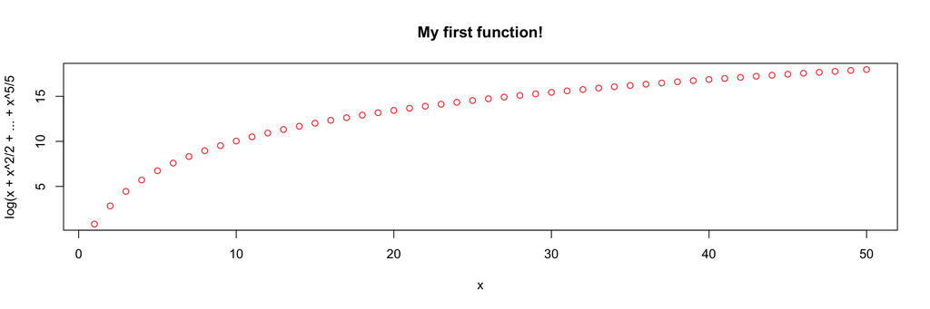

```r
x <- 1:50
y <- my_function(1:50)


plot(x,y, col="red", ylab="log(x + x^2/2 + ... + x^5/5", main="My first function!")
```